# Taylor-Module3-AlgorithmicBias

#### atayl136

#### AI Values and Ethics EN.705.612

## Module 3 - Algorithmic Bias

## Detecting Gender Bias in the Augmented COMPAS Data Set

**Introduction**

The landmark ProPublica expose done in 2016 revealed rampant racial bias in the COMPAS (Correctional Offender Management Profiling for Alternative Sanctions) model used for alternative sentencing recommendations in jurisdictions all across America. While calibration and accuracy were comparable across whites and blacks, the range and disparity of outcomes in the case of COMPAS errors was grossly unfair. This turns out to be a good example of the "impossibility theorem", that some definitions of fairness can't be maximized for certain data sets. In this case, equal treatment can't be optimized because of differing baseline rates of recidivism between racial groups. The fact is that different races do offend at different rates, but it is illegal to treat them preferentially. This is the core of the problem with the COMPAS model.

In this notebook, we will investigate a slightly augmented version of that same data, looking for signs of gender bias in the numbers. I will do this with a variety of techniques in Python:

1. Descriptive Statistics (pandas)
2. Visualization (matplotlib)
3. Correlation Analysis (pandas)
4. Bias and Fairness Metrics (aif360)

After the code is run and the results presented, I will circle back and answer the following prompt (graphs will not be repeated for brevity):

*Analyze the data to show whether the COMPAS scores (decile_score variable) are fair related to recidivism. Use the two_year_recid variable. The ProPublica analysis focused on the comparison of African-Americans and Caucasians. Show an analysis of gender as another possible protected class bias.*

What is the best data-based argument that the COMPAS algorithm is fair related to gender? Support with at least one table or graph.

What is the best data-based argument that the COMPAS algorithm is unfair related to gender? Support with at least one table or graph.

Subsequently, I will investigate gender unblinded correction answering these questions:

*Read the online article, "Can You Make AI faired than a judge?" at https://www.technologyreview.com/2019/10/17/75285/ai-fairer-than-judge This exercise shows the implications of unbalance classes for simultaneously satisfying multiple different fairness criteria. This exercise hints at a radical suggestion, which is to make the algorithm no longer- race-blind, but instead use different criteria for black an*d white defendants.*

*Implement this suggestion in the gender data and analyze the results. (The simplest intervention would have been to simply add or subtract a constant from COMPAS scores for one gender, e.g., -1* for female defendants.)*

2a) What effects does this have on different fairness metrics?

2b) What are the implications of this correction for Northpointe's defense of the COMPAS algorithm as demographic-blind, well calibrated, and equally accurate for all groups?

Lastly, I will jot down some notes to support my in-class response where I will consider structural sources of bias that may be outside of the algorithm.

*Use the classroom discussion to present three potential structural risks that should be considered. (You can use either the race or gender example for this.) Refer to at least two of the categories from the Harm Frameworks paper. (Suresh, H. & Guttag, J. (2021). A Framework for understanding sources of harm througho1901.10002v4)*

```python
# 1. Descriptive Statistics

import pandas as pd

# Load dataset
data = pd.read_csv(r"C:\Users\Putna\OneDrive - Johns Hopkins\Documents\Johns Hopkins\AI Values and Ethics\Module 3 HW\Taylor-Module3-AlgorithmicBias\compas_synthetic_2024.csv")

# Descriptive statistics for numerical features
numerical_summary = data.describe()

# print head
print('Data Head')
print(data.head())
print('\n\n')

# Value counts for categorical features to identify imbalance
for column in data.select_dtypes(include=['object']).columns:
    print(f"Value counts for {column}:\n{data[column].value_counts()}\n")
```

```
Data Head
   id              name  decile_score risk_level  age   sex              race  \
0   1  miguel hernandez             1        Low   69  Male             Other
1   3       kevon dixon             3        Low   34  Male  African-American
2   4          ed philo             4        Low   24  Male  African-American
3   7      marsha miles             1        Low   44  Male             Other
4   8     edward riddle             6     Medium   41  Male         Caucasian

   priors_count c_charge_degree  juv_fel_count  ...  criminal_attitude  \
0             0               F              0  ...                  4
1             0               F              0  ...                  5
2             4               F              0  ...                  5
3             0               M              0  ...                  5
4            14               F              0  ...                  5

   criminal_associates  financial_problems  substance_abuse  noncompliance  \
0                    4                   3                2              4
1                    5                   5                8              3
2                    3                   3                6              4
3                    5                   4                2              4
4                    3                   7                4              5

   social_environment  vocational  is_recid  two_year_recid  high_risk
0                   8          10         0               0        Low
1                   3          10         1               1        Low
2                   3          10         1               1        Low
3                   6           8         0               0        Low
4                   5           8         1               1       High

[5 rows x 21 columns]



Value counts for name:
anthony smith          3
john grant             2
james scott            2
patrick frazier        2
finest williams        2
                      ..
```

[output cut: 21 more lines]

```
Hispanic             509
Other                343
Asian                 31
Native American       11
Name: race, dtype: int64

Value counts for c_charge_degree:
F    3970
M    2202
Name: c_charge_degree, dtype: int64

Value counts for high_risk:
Low     4003
High    2169
Name: high_risk, dtype: int64
```

The data set is unbalanced between male and females. let's correct that by downsampling the males.

```python
# Separate the dataset into male and female records
df_male = data[data['sex'] == 'Male']
df_female = data[data['sex'] == 'Female']

# Downsample the male records
df_male_downsampled = df_male.sample(n=len(df_female), random_state=42)  # ensure reproducibility

# Combine back to a balanced dataset
df_balanced = pd.concat([df_male_downsampled, df_female])

# Shuffle the dataset to mix male and female records
df_balanced = df_balanced.sample(frac=1, random_state=42).reset_index(drop=True)

# Display the new gender distribution
gender_counts_balanced = df_balanced['sex'].value_counts()
print(gender_counts_balanced)
print('\n\n')

# Drop specified columns from the DataFrame
df_balanced = df_balanced.drop(columns=['id', 'name', 'risk_level', 'race', 'high_risk'])

# Convert 'sex' column: 0 for Male and 1 for Female
df_balanced['sex'] = df_balanced['sex'].replace({'Male': 0, 'Female': 1})

# Convert 'c_charge_degree' column: 0 for M and 1 for F
df_balanced['c_charge_degree'] = df_balanced['c_charge_degree'].replace({'M': 0, 'F': 1})

# Iterate over each column in the DataFrame
for col in df_balanced.columns:
    # Check if the column is of type object (string)
    if df_balanced[col].dtype == 'object' or 'int64':
        # Attempt to convert to float
        try:
            df_balanced[col] = df_balanced[col].astype(float)
        except ValueError:
            print(f"Conversion failed for column: {col}. Column may contain non-numeric strings.")

df_balanced['decile_score'] = df_balanced['decile_score'].replace(0, 10.0)


# Verify the result
print(df_balanced.dtypes)

# Display the first few rows of the updated DataFrame to verify the changes
print(df_balanced.head())
```

```
Female    1175
Male      1175
Name: sex, dtype: int64



decile_score           float64
age                    float64
sex                    float64
priors_count           float64
c_charge_degree        float64
juv_fel_count          float64
family_criminality     float64
criminal_attitude      float64
criminal_associates    float64
financial_problems     float64
substance_abuse        float64
noncompliance          float64
social_environment     float64
vocational             float64
is_recid               float64
two_year_recid         float64
dtype: object
   decile_score   age  sex  priors_count  c_charge_degree  juv_fel_count  \
0           8.0  30.0  1.0           8.0              1.0            0.0
1           4.0  25.0  0.0           0.0              1.0            0.0
2           1.0  62.0  1.0           1.0              0.0            0.0
3           7.0  20.0  0.0           2.0              1.0            0.0
4           9.0  26.0  1.0           2.0              1.0            0.0

   family_criminality  criminal_attitude  criminal_associates  \
0                 4.0                8.0                  6.0
1                10.0                4.0                  4.0
2                 3.0                6.0                  3.0
3                 1.0                7.0                  7.0
4                 3.0                6.0                 10.0

   financial_problems  substance_abuse  noncompliance  social_environment  \
0                 5.0              6.0            8.0                 4.0
1                 4.0              5.0            4.0                 4.0
2                 2.0              4.0            6.0                 7.0
3                 5.0              8.0            8.0                 3.0
4                 9.0              8.0            6.0                 4.0

   vocational  is_recid  two_year_recid
0        10.0       1.0             1.0
1         7.0       1.0             1.0
2        10.0       1.0             1.0
3         5.0       1.0             1.0
4         5.0       1.0             1.0
```

```python
# Descriptive Statistics, cont.

# Set display options to show all columns
pd.options.display.max_columns = None

# Descriptive statistics for numerical features, grouped by 'sex'
numerical_summary_sex = df_balanced.groupby('sex').describe()

# Get the number of columns
num_columns = len(numerical_summary_sex.columns)

# Define the number of columns to display in each table
columns_per_table = 8

# Calculate the number of tables
num_tables = num_columns // columns_per_table + (num_columns % columns_per_table > 0)

# Iterate over the tables
for i in range(num_tables):
    # Get the start and end index for the columns
    start_idx = i * columns_per_table
    end_idx = min((i + 1) * columns_per_table, num_columns)

    # Subset the DataFrame to get the columns for this table
    subset_columns = numerical_summary_sex.columns[start_idx:end_idx]
    subset_table = numerical_summary_sex[subset_columns]

    # Display the table
    display(subset_table)
    print("\n")
```

| sex | decile_score count | decile_score mean | decile_score std | decile_score min | decile_score 25% | decile_score 50% | decile_score 75% | decile_score max |
| --- | --- | --- | --- | --- | --- | --- | --- | --- |
| 0.0 | 1175.0 | 4.525106 | 2.877246 | 1.0 | 2.0 | 4.0 | 7.0 | 10.0 |
| 1.0 | 1175.0 | 4.063830 | 2.651895 | 1.0 | 2.0 | 4.0 | 6.0 | 10.0 |

| sex | age count | age mean | age std | age min | age 25% | age 50% | age 75% | age max |
| --- | --- | --- | --- | --- | --- | --- | --- | --- |
| 0.0 | 1175.0 | 34.258723 | 11.909202 | 19.0 | 25.0 | 30.0 | 41.0 | 83.0 |
| 1.0 | 1175.0 | 34.737872 | 11.457323 | 19.0 | 25.5 | 32.0 | 42.0 | 75.0 |

| sex | priors_count count | priors_count mean | priors_count std | priors_count min | priors_count 25% | priors_count 50% | priors_count 75% | priors_count max |
| --- | --- | --- | --- | --- | --- | --- | --- | --- |
| 0.0 | 1175.0 | 3.531064 | 4.837620 | 0.0 | 0.0 | 2.0 | 5.0 | 37.0 |
| 1.0 | 1175.0 | 2.085106 | 3.542092 | 0.0 | 0.0 | 1.0 | 3.0 | 30.0 |

| sex | c_charge_degree count | c_charge_degree mean | c_charge_degree std | c_charge_degree min | c_charge_degree 25% | c_charge_degree 50% | c_charge_degree 75% | c_charge_degree max |
| --- | --- | --- | --- | --- | --- | --- | --- | --- |
| 0.0 | 1175.0 | 0.644255 | 0.478942 | 0.0 | 0.0 | 1.0 | 1.0 | 1.0 |
| 1.0 | 1175.0 | 0.582128 | 0.493419 | 0.0 | 0.0 | 1.0 | 1.0 | 1.0 |

| sex | juv_fel_count count | juv_fel_count mean | juv_fel_count std | juv_fel_count min | juv_fel_count 25% | juv_fel_count 50% | juv_fel_count 75% | juv_fel_count max |
| --- | --- | --- | --- | --- | --- | --- | --- | --- |
| 0.0 | 1175.0 | 0.057872 | 0.340438 | 0.0 | 0.0 | 0.0 | 0.0 | 5.0 |
| 1.0 | 1175.0 | 0.011064 | 0.139530 | 0.0 | 0.0 | 0.0 | 0.0 | 3.0 |

| sex | family_criminality count | family_criminality mean | family_criminality std | family_criminality min | family_criminality 25% | family_criminality 50% | family_criminality 75% | family_criminality max |
| --- | --- | --- | --- | --- | --- | --- | --- | --- |
| 0.0 | 1175.0 | 4.902128 | 1.997389 | -3.0 | 4.0 | 5.0 | 6.0 | 12.0 |
| 1.0 | 1175.0 | 4.995745 | 2.033991 | -1.0 | 4.0 | 5.0 | 6.0 | 12.0 |

| sex | criminal_attitude count | criminal_attitude mean | criminal_attitude std | criminal_attitude min | criminal_attitude 25% | criminal_attitude 50% | criminal_attitude 75% | criminal_attitude max |
| --- | --- | --- | --- | --- | --- | --- | --- | --- |
| 0.0 | 1175.0 | 4.997447 | 1.999785 | -2.0 | 4.0 | 5.0 | 6.0 | 13.0 |
| 1.0 | 1175.0 | 5.022128 | 1.984485 | -2.0 | 4.0 | 5.0 | 6.0 | 12.0 |

| sex | criminal_associates count | criminal_associates mean | criminal_associates std | criminal_associates min | criminal_associates 25% | criminal_associates 50% | criminal_associates 75% | criminal_associates max |
| --- | --- | --- | --- | --- | --- | --- | --- | --- |
| 0.0 | 1175.0 | 5.065532 | 2.030843 | -1.0 | 4.0 | 5.0 | 6.0 | 11.0 |
| 1.0 | 1175.0 | 5.092766 | 1.931292 | 0.0 | 4.0 | 5.0 | 6.0 | 11.0 |

| sex | financial_problems count | financial_problems mean | financial_problems std | financial_problems min | financial_problems 25% | financial_problems 50% | financial_problems 75% | financial_problems max |
| --- | --- | --- | --- | --- | --- | --- | --- | --- |
| 0.0 | 1175.0 | 5.027234 | 1.980555 | -3.0 | 4.0 | 5.0 | 6.0 | 12.0 |
| 1.0 | 1175.0 | 4.994894 | 1.973411 | -1.0 | 4.0 | 5.0 | 6.0 | 11.0 |

| sex | substance_abuse count | substance_abuse mean | substance_abuse std | substance_abuse min | substance_abuse 25% | substance_abuse 50% | substance_abuse 75% | substance_abuse max |
| --- | --- | --- | --- | --- | --- | --- | --- | --- |
| 0.0 | 1175.0 | 5.043404 | 2.074175 | 0.0 | 4.0 | 5.0 | 7.0 | 12.0 |
| 1.0 | 1175.0 | 4.806809 | 1.932671 | -1.0 | 3.0 | 5.0 | 6.0 | 11.0 |

| sex | noncompliance count | noncompliance mean | noncompliance std | noncompliance min | noncompliance 25% | noncompliance 50% | noncompliance 75% | noncompliance max |
| --- | --- | --- | --- | --- | --- | --- | --- | --- |
| 0.0 | 1175.0 | 5.044255 | 2.078875 | 0.0 | 4.0 | 5.0 | 6.0 | 11.0 |
| 1.0 | 1175.0 | 4.736170 | 1.946957 | -1.0 | 3.0 | 5.0 | 6.0 | 11.0 |

| sex | social_environment count | social_environment mean | social_environment std | social_environment min | social_environment 25% | social_environment 50% | social_environment 75% | social_environment max |
| --- | --- | --- | --- | --- | --- | --- | --- | --- |
| 0.0 | 1175.0 | 4.938723 | 1.999486 | 0.0 | 4.0 | 5.0 | 6.0 | 15.0 |
| 1.0 | 1175.0 | 5.036596 | 2.008378 | -1.0 | 4.0 | 5.0 | 6.0 | 13.0 |

| sex | vocational count | vocational mean | vocational std | vocational min | vocational 25% | vocational 50% | vocational 75% | vocational max |
| --- | --- | --- | --- | --- | --- | --- | --- | --- |
| 0.0 | 1175.0 | 7.941277 | 2.034403 | 2.0 | 7.0 | 8.0 | 9.0 | 14.0 |
| 1.0 | 1175.0 | 7.998298 | 1.979451 | 2.0 | 7.0 | 8.0 | 9.0 | 14.0 |

| sex | is_recid count | is_recid mean | is_recid std | is_recid min | is_recid 25% | is_recid 50% | is_recid 75% | is_recid max |
| --- | --- | --- | --- | --- | --- | --- | --- | --- |
| 0.0 | 1175.0 | 0.514043 | 0.500016 | 0.0 | 0.0 | 1.0 | 1.0 | 1.0 |
| 1.0 | 1175.0 | 0.370213 | 0.483067 | 0.0 | 0.0 | 0.0 | 1.0 | 1.0 |

| sex | two_year_recid count | two_year_recid mean | two_year_recid std | two_year_recid min | two_year_recid 25% | two_year_recid 50% | two_year_recid 75% | two_year_recid max |
| --- | --- | --- | --- | --- | --- | --- | --- | --- |
| 0.0 | 1175.0 | 0.481702 | 0.499878 | 0.0 | 0.0 | 0.0 | 1.0 | 1.0 |
| 1.0 | 1175.0 | 0.351489 | 0.477639 | 0.0 | 0.0 | 0.0 | 1.0 | 1.0 |

```python
mean_scores = df_balanced.groupby('sex')['decile_score'].mean()
median_scores = df_balanced.groupby('sex')['decile_score'].median()

print("Mean Decile Scores:\n", mean_scores)
print("\nMedian Decile Scores:\n", median_scores)
```

```
Mean Decile Scores:
 sex
0.0    4.525106
1.0    4.063830
Name: decile_score, dtype: float64

Median Decile Scores:
 sex
0.0    4.0
1.0    4.0
Name: decile_score, dtype: float64
```

Mean scores for males are hugher, prima facie evidence of bias.

```python
recidivism_rate = df_balanced.groupby('sex')['two_year_recid'].mean()

print("Recidivism Rate by Gender:\n", recidivism_rate)
```

```
Recidivism Rate by Gender:
 sex
0.0    0.481702
1.0    0.351489
Name: two_year_recid, dtype: float64
```

The recidivism rate is higher for Males. Is there a bias against males that may in fact be defended by this metric?

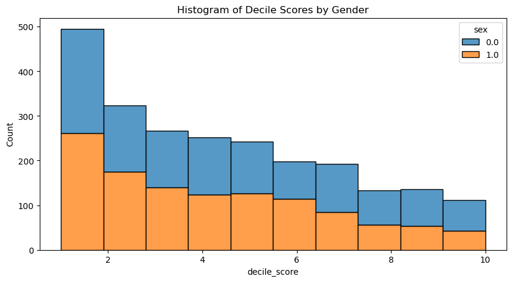

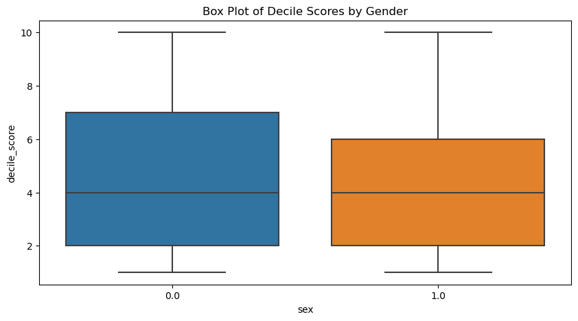

```python
# 2. Visualization

import seaborn as sns
import matplotlib.pyplot as plt

# Histogram
plt.figure(figsize=(10, 5))
sns.histplot(data=df_balanced, x='decile_score', hue='sex', multiple='stack', bins=10)
plt.title('Histogram of Decile Scores by Gender')
plt.show()

# Box Plot
plt.figure(figsize=(10, 5))
sns.boxplot(x='sex', y='decile_score', data=df_balanced)
plt.title('Box Plot of Decile Scores by Gender')
plt.show()
```

In the box plot we see a greater interquartile range for the Males, indicating a skew towards worse scores.

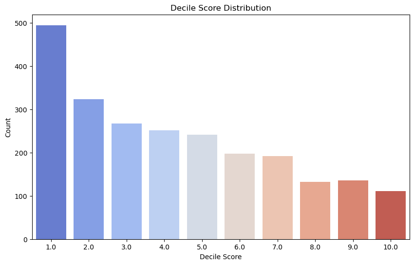

```python
# Decile score distribution

plt.figure(figsize=(10, 6))
sns.countplot(data=df_balanced, x="decile_score", palette="coolwarm")
plt.title('Decile Score Distribution')
plt.xlabel('Decile Score')
plt.ylabel('Count')
plt.show()
```

This is just an overall distribution for clarity.

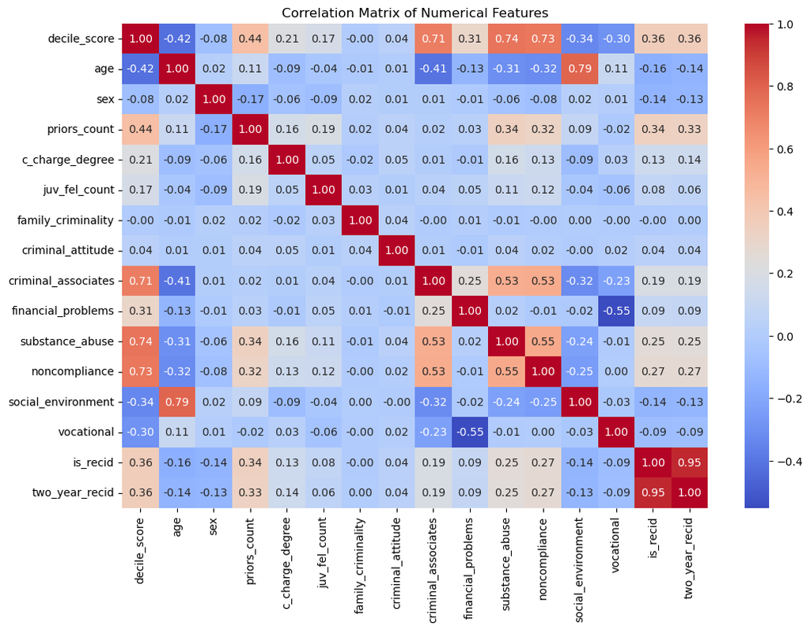

```python
# Correlation Analysis

# Calculate correlation matrix
correlation_matrix = df_balanced.corr()

# Visualize the correlation matrix
plt.figure(figsize=(12, 8))
sns.heatmap(correlation_matrix, annot=True, cmap='coolwarm', fmt=".2f")
plt.title('Correlation Matrix of Numerical Features')
plt.show()
```

#### Interpretation of key metrics

This weak negative correlation suggests a slight tendency for males (coded as `0`) to receive higher decile scores than females (coded as `1`). While the magnitude of this correlation might seem small, it indicates a systemic disparity in scoring that could have significant implications for fairness and justice. This gender disparity in scoring, even if seemingly minor, is substantial enough to raise concerns about the equitable treatment of individuals within the scoring system. a small difference over a lot of cases is a lot of injustice.

The negative correlation, though relatively weak, points towards males having a slightly higher rate of recidivism than females. This difference, while not extreme in magnitude, underscores a potential injustice in the way recidivism outcomes are distributed across genders: Are they overpoliced, arrested more often? Police have substantial leeway in deciding charges. It suggests that the underlying factors leading to recidivism may be influenced by systemic biases that disproportionately affect males, highlighting an area of concern for fairness in the criminal justice process.

**Correlation between `decile_score` and `two_year_recid` (0.365487):**

A moderate positive correlation here indicates that higher decile scores correlate with a higher likelihood of recidivism, lending some credence to the effectiveness of the decile scoring system in predicting recidivism risk. However, the existence of gender disparities in both scoring and recidivism rates calls into question the fairness and justice of applying these scores uniformly across genders. The substantial correlation suggests that while the scoring system may have predictive validity, it does not necessarily do so in a manner that is equitable for all. And how substanital is the correlation, actually? Intuitively, a 0.37 correlation is rather weak evidence of COMPAS's usefulness.

**Other Correlations**

Other correlations that stand out are priors_count, substance_abuse, and noncomplaince. The remaining factors score rather low in correlation:

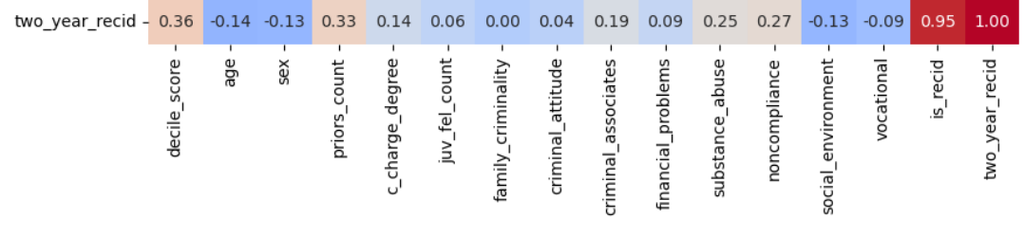

#### Looking for Bias, Summary

The presence of negative correlations between `sex` and both `decile_score` and `two_year_recid` reveals a subtle but significant bias in how risk is assessed and distributed among genders, with males being more adversely affected. These findings are not merely statistical anomalies but indicators of systemic bias that can perpetuate injustice, particularly for males who are systematically assigned higher risk scores and exhibit higher recidivism rates.

The moderate positive correlation between `decile_score` and `two_year_recid`, while supporting the scoring system's predictive ability, also emphasizes the need for a critical evaluation of the fairness of these predictions. The observed gender disparities necessitate a thorough review and adjustment of the scoring system to ensure it is administered justly and equitably.

```python
# Bias and Fairness Analysis - Threshold 4 and below

from aif360.datasets import StandardDataset
from aif360.metrics import BinaryLabelDatasetMetric
from aif360.algorithms.preprocessing import Reweighing
import warnings
warnings.filterwarnings('ignore')

# Define a threshold for low (favorable) decile scores
threshold = 4

# Create a new binary column where 1 indicates a low (favorable) decile score
df_balanced['favorable_score'] = df_balanced['decile_score'].apply(lambda x: 1 if x <= threshold else 0)

from aif360.datasets import StandardDataset

# Assuming 'favorable_score' is already in our DataFrame and 'sex' is encoded as 0 for Male and 1 for Female
# Here, we consider 'Female' as the privileged group for demonstration

aif360_dataset = StandardDataset(df_balanced,
                                 label_name='favorable_score',  # The target label you created
                                 favorable_classes=[1],  # Indicating that lower scores (binarized as 1) are favorable
                                 protected_attribute_names=['sex'],  # Protected attribute you're analyzing for bias
                                 privileged_classes=[[1]])  # Indicating 'Female' as the privileged group


# Measure fairness metrics before mitigation
metric = BinaryLabelDatasetMetric(aif360_dataset,
                                  unprivileged_groups=[{'sex': 0}],
                                  privileged_groups=[{'sex': 1}])
print("Disparate Impact:", metric.disparate_impact())
print("Statistical Parity Difference:", metric.statistical_parity_difference())

# Apply reweighing to mitigate bias
reweighing = Reweighing(unprivileged_groups=[{'sex': 0}],
                        privileged_groups=[{'sex': 1}])
aif360_dataset_rw = reweighing.fit_transform(aif360_dataset)

# Measure fairness metrics after mitigation
metric_rw = BinaryLabelDatasetMetric(aif360_dataset_rw,
                                     unprivileged_groups=[{'sex': 0}],
                                     privileged_groups=[{'sex': 1}])
print("Disparate Impact after reweighing:", metric_rw.disparate_impact())
print("Statistical Parity Difference after reweighing:", metric_rw.statistical_parity_difference())
```

[output not shown]

```
Disparate Impact: 0.9141630901287553
Statistical Parity Difference: -0.051063829787234116
Disparate Impact after reweighing: 0.9999999999999998
Statistical Parity Difference after reweighing: -1.1102230246251565e-16
```

I chose the Females as the priviledged group from a the earlier exploration. Let's analyze the results with respect to the decile_score being lower for favorable outcomes and considering the sex attribute for fairness evaluation. The threshold for a "low" score was considered to be 4 and below.

```python
# Bias and Fairness Analysis - Threshold 5 and below

from aif360.datasets import StandardDataset
from aif360.metrics import BinaryLabelDatasetMetric
from aif360.algorithms.preprocessing import Reweighing
import warnings
warnings.filterwarnings('ignore')

# Define a threshold for low (favorable) decile scores
threshold = 5

# Create a new binary column where 1 indicates a low (favorable) decile score
df_balanced['favorable_score'] = df_balanced['decile_score'].apply(lambda x: 1 if x <= threshold else 0)

from aif360.datasets import StandardDataset

# Assuming 'favorable_score' is already in our DataFrame and 'sex' is encoded as 0 for Male and 1 for Female
# Here, we consider 'Female' as the privileged group for demonstration

aif360_dataset = StandardDataset(df_balanced,
                                 label_name='favorable_score',  # The target label you created
                                 favorable_classes=[1],  # Indicating that lower scores (binarized as 1) are favorable
                                 protected_attribute_names=['sex'],  # Protected attribute you're analyzing for bias
                                 privileged_classes=[[1]])  # Indicating 'Female' as the privileged group


# Measure fairness metrics before mitigation
metric = BinaryLabelDatasetMetric(aif360_dataset,
                                  unprivileged_groups=[{'sex': 0}],
                                  privileged_groups=[{'sex': 1}])
print("Disparate Impact:", metric.disparate_impact())
print("Statistical Parity Difference:", metric.statistical_parity_difference())

# Apply reweighing to mitigate bias
reweighing = Reweighing(unprivileged_groups=[{'sex': 0}],
                        privileged_groups=[{'sex': 1}])
aif360_dataset_rw = reweighing.fit_transform(aif360_dataset)

# Measure fairness metrics after mitigation
metric_rw = BinaryLabelDatasetMetric(aif360_dataset_rw,
                                     unprivileged_groups=[{'sex': 0}],
                                     privileged_groups=[{'sex': 1}])
print("Disparate Impact after reweighing:", metric_rw.disparate_impact())
print("Statistical Parity Difference after reweighing:", metric_rw.statistical_parity_difference())
```

```
Disparate Impact: 0.9128329297820824
Statistical Parity Difference: -0.061276595744680806
Disparate Impact after reweighing: 0.9999999999999997
Statistical Parity Difference after reweighing: -2.220446049250313e-16
```

Granting the middle to the "low" group shows a similar disparate impact and a slightly increased Statistical Parity Difference. The SPD has become more negative (-0.061) compared to the previous threshold (-0.051), indicating an increase in the bias against the unprivileged group. This means that the probability gap between the unprivileged and privileged groups receiving a favorable outcome has widened slightly, from a 5.1% disadvantage to about a 6.1% disadvantage for the unprivileged group. So, it's even worse for the Males.

```python
# Bias and Fairness Analysis - Threshold 7 and below

from aif360.datasets import StandardDataset
from aif360.metrics import BinaryLabelDatasetMetric
from aif360.algorithms.preprocessing import Reweighing
import warnings
warnings.filterwarnings('ignore')

# Define a threshold for low (favorable) decile scores
threshold = 7

# Create a new binary column where 1 indicates a low (favorable) decile score
df_balanced['favorable_score'] = df_balanced['decile_score'].apply(lambda x: 1 if x <= threshold else 0)

from aif360.datasets import StandardDataset

# Assuming 'favorable_score' is already in our DataFrame and 'sex' is encoded as 0 for Male and 1 for Female
# Here, we consider 'Female' as the privileged group for demonstration

aif360_dataset = StandardDataset(df_balanced,
                                 label_name='favorable_score',  # The target label you created
                                 favorable_classes=[1],  # Indicating that lower scores (binarized as 1) are favorable
                                 protected_attribute_names=['sex'],  # Protected attribute you're analyzing for bias
                                 privileged_classes=[[1]])  # Indicating 'Female' as the privileged group


# Measure fairness metrics before mitigation
metric = BinaryLabelDatasetMetric(aif360_dataset,
                                  unprivileged_groups=[{'sex': 0}],
                                  privileged_groups=[{'sex': 1}])
print("Disparate Impact:", metric.disparate_impact())
print("Statistical Parity Difference:", metric.statistical_parity_difference())

# Apply reweighing to mitigate bias
reweighing = Reweighing(unprivileged_groups=[{'sex': 0}],
                        privileged_groups=[{'sex': 1}])
aif360_dataset_rw = reweighing.fit_transform(aif360_dataset)

# Measure fairness metrics after mitigation
metric_rw = BinaryLabelDatasetMetric(aif360_dataset_rw,
                                     unprivileged_groups=[{'sex': 0}],
                                     privileged_groups=[{'sex': 1}])
print("Disparate Impact after reweighing:", metric_rw.disparate_impact())
print("Statistical Parity Difference after reweighing:", metric_rw.statistical_parity_difference())
```

```
Disparate Impact: 0.923828125
Statistical Parity Difference: -0.06638297872340426
Disparate Impact after reweighing: 0.9999999999999996
Statistical Parity Difference after reweighing: -3.3306690738754696e-16
```

### Algorithm Calibration

**Uniform Bias and Calibration:** If the bias is uniform and the algorithm's predictions are consistent with actual outcomes across different groups, the algorithm might still be considered calibrated correctly. However, calibration alone does not guarantee fairness. An algorithm can be calibrated but still exhibit bias if it systematically underestimates or overestimates the likelihood of positive outcomes for certain groups.

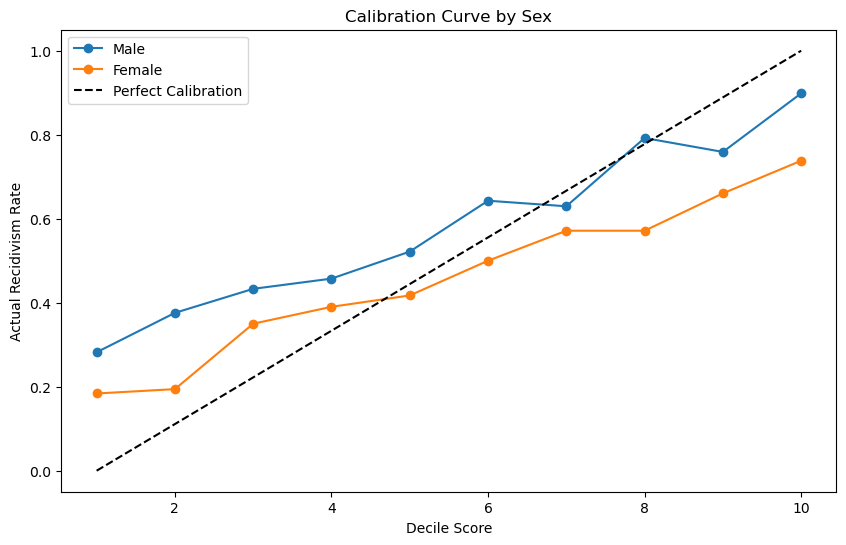

```python
import matplotlib.pyplot as plt
import numpy as np

def plot_calibration_curve(df, sex_value, label='Group'):
    """Plots the calibration curve for a specified sex value within the DataFrame.

    Args:
        df (DataFrame): The data frame containing the scores and outcomes.
        sex_value (int): The value in the 'sex' column to filter by (0 for Male, 1 for Female).
        label (str): The label for the plot.
    """
    # Filter the DataFrame by sex
    df_group = df[df['sex'] == sex_value]

    # Group by decile_score and calculate the actual positive outcome rate
    outcome_rate = df_group.groupby('decile_score')['is_recid'].mean()

    # Plot
    plt.plot(outcome_rate.index, outcome_rate.values, marker='o', label=label)

# Prepare the plot
plt.figure(figsize=(10, 6))

# Plot calibration curves
plot_calibration_curve(df_balanced, 0, 'Male')
plot_calibration_curve(df_balanced, 1, 'Female')

# Add plot decorations
plt.plot([1, 10], [0, 1], 'k--', label='Perfect Calibration')
plt.title('Calibration Curve by Sex')
plt.xlabel('Decile Score')
plt.ylabel('Actual Recidivism Rate')
plt.legend()
plt.show()
```

The algorithm seems somehwhat calibrated as Northpointe claims, here. But, in a moment I will restate the relationship and change the aspect ratio of the chart for clarity. The hills and valleys catch the eye.

### Answering Part 1 Questions: Question 1

Q: What is the best data-based argument that the COMPAS algorithm is fair related to gender? Support with at least one table or graph.

Referencing above, I think the single best data-based argument that COMPAS is fair with respect to gender is the fact that male recidivism rates are higher on the whole for Males as opposed to Females. If it is true that men are more likely to offend than women, higher scores globally would be merited. The box plots, correlation scores and fairness metrics all display this tendancy.

```
AUC Score for Males: 0.723
AUC Score for Females: 0.692
```

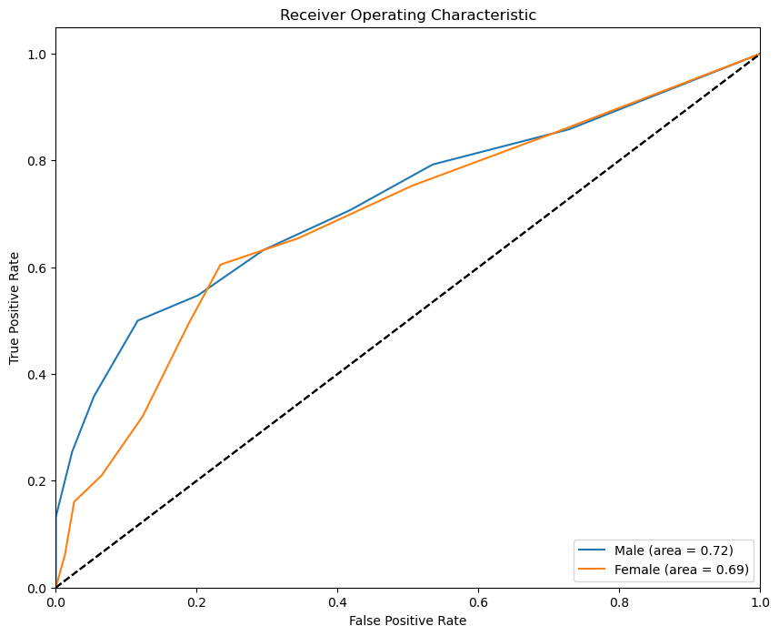

```python
# Step 1: Group-wise Logistic Regression Analysis

from sklearn.metrics import roc_auc_score
from sklearn.model_selection import train_test_split
from sklearn.linear_model import LogisticRegression
from sklearn.metrics import roc_curve, auc

def logistic_regression_analysis(X, y):
    """Performs logistic regression analysis and returns the AUC score."""
    X_train, X_test, y_train, y_test = train_test_split(X, y, test_size=0.2, random_state=42)
    model = LogisticRegression()
    model.fit(X_train, y_train)
    y_pred_proba = model.predict_proba(X_test)[:, 1]  # Probabilities for the positive class
    return roc_auc_score(y_test, y_pred_proba)

# Separate the dataset by gender
male_data = df_balanced[df_balanced['sex'] == 0]
female_data = df_balanced[df_balanced['sex'] == 1]

# Perform logistic regression analysis for males
X_male = male_data[['decile_score']]
y_male = male_data['two_year_recid']
auc_male = logistic_regression_analysis(X_male, y_male)

# Perform logistic regression analysis for females
X_female = female_data[['decile_score']]
y_female = female_data['two_year_recid']
auc_female = logistic_regression_analysis(X_female, y_female)

print(f"AUC Score for Males: {auc_male:.3f}")
print(f"AUC Score for Females: {auc_female:.3f}")
print('\n\n')

def plot_roc_curve(data, title):
    # Prepare the data
    X = data[['decile_score']]
    y = data['two_year_recid']

    # Split the data
    X_train, X_test, y_train, y_test = train_test_split(X, y, test_size=0.2, random_state=42)

    # Initialize and train the logistic regression model
    model = LogisticRegression()
    model.fit(X_train, y_train)

    # Predict probabilities
    y_pred_proba = model.predict_proba(X_test)[:, 1]

    # Calculate ROC curve
    fpr, tpr, _ = roc_curve(y_test, y_pred_proba)
    roc_auc = auc(fpr, tpr)

    # Plot
    plt.plot(fpr, tpr, label=f'{title} (area = {roc_auc:.2f})')
    plt.plot([0, 1], [0, 1], 'k--')  # Diagonal line
    plt.xlim([0.0, 1.0])
    plt.ylim([0.0, 1.05])
    plt.xlabel('False Positive Rate')
    plt.ylabel('True Positive Rate')
    plt.title('Receiver Operating Characteristic')
    plt.legend(loc="lower right")

# Plot ROC curves
plt.figure(figsize=(10, 8))
plot_roc_curve(male_data, 'Male')
plot_roc_curve(female_data, 'Female')
plt.show()
```

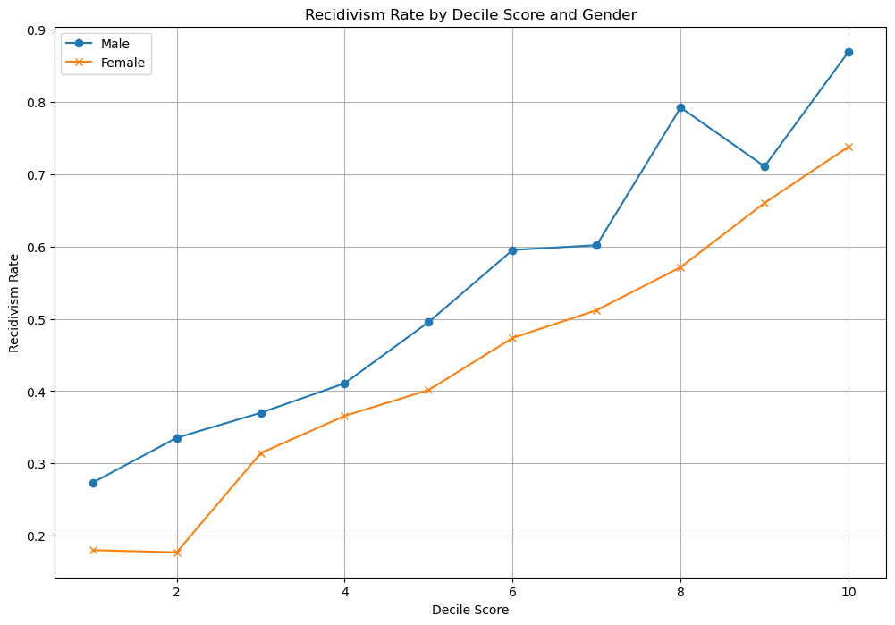

```python
# Step 2: Comparison of Recidivism Rates by Gender and Decile Score - what the Calibration Plot really means

# Calculate recidivism rates by decile score for each gender
recidivism_rates_male = male_data.groupby('decile_score')['two_year_recid'].mean()
recidivism_rates_female = female_data.groupby('decile_score')['two_year_recid'].mean()

# Plotting the recidivism rates by decile score for each gender
plt.figure(figsize=(12, 8))
recidivism_rates_male.plot(label='Male', marker='o')
recidivism_rates_female.plot(label='Female', marker='x')
plt.title('Recidivism Rate by Decile Score and Gender')
plt.xlabel('Decile Score')
plt.ylabel('Recidivism Rate')
plt.legend()
plt.grid(True)
plt.show()
```

Both of these plots could lead us to believe that, respectively, COMPAS is a fairly accurate predictor (comparing genders - AUC Score for Males: 0.723, AUC Score for Females: 0.692) and that the difference derives from differing recidivism rates.

In addition to recidivism, males exhibit higher counts on priors, higher rates of substance abuse, and greater noncompliance (see tables above). Next to the decile_score itself, these are the factors with the highest correlation to the two_year_recid metric.

These are additional considerations that indicate the discrepancy could be a fair one: they are riskier individuals.

### Answering Part 1 Questions: Question 2

Q: What is the best data-based argument that the COMPAS algorithm is unfair related to gender? Support with at least one table or graph.

Inverting these facts, we see an argument that COMPAS is biased. The idea is that males are over-policed, arrested, and charged more often than females. This could be the cause of the higher recidivism rates, and also greater number of priors. The substance abuse metric should indicate to us that what males need is indeed alternative sentencing, like treatment programs, instead of stringent sentencing and being denied release. The noncompliance metric could be indicator that bail terms are unfair and harder to comply with. The thrust of this whole argument is that the system is unfairly persuing and prosecuting males and the COMPAS system is not correcting for this discrimination happening in the field and in the courtroom; it is exacerbating it. Looking above at the calibration curve for males, we see suspicious "bumps" just at/above the dividing line for high risk, and smack in the middle of the high_risk category. This could indicate that the algorithm is slightly biased to putting riisky males into the center and higher end of the measure, gravitating around the center of the upper risk category (5-10, 'high_risk' metric). If I had to choose one chart for the "unfair" argument, it would be the one immediately above: that the male recidivism rate curiously protrudes at a score of 8 (the calibration curve restated differently), yet declines at 9 and peaks at 10. The decline into 9 reflects that something is wrong with the common sense reasoning of the calibration curve, those ranked 9 are less likely to reoffend than those ranked 8. This is not an argument for fairness, because the trend of recidivism is not in fact smooth. Even if it is under-scoring the 8th decile, it is over-scoring the 9th. This is a point against Northpointe's defense of correct calibration.

### Answering Part 2 Questions: Question 2a

Implement this suggestion (gender-awareness of the scores) in the gender data and analyze the results. (The simplest intervention would have been to simply add or subtract a constant from COMPAS scores for one gender, e.g., -1* for female defendants.)

2a) What effects does this have on different fairness metrics?

The article "Can you make AI fairer than a judge? Play our courtroom algorithm game" from MIT Technology Review delves into the complexities of using algorithms, specifically the COMPAS algorithm, in the criminal justice system to predict the likelihood of defendants being rearrested. It highlights the inherent challenges in achieving fairness through these predictive tools, especially when considering different fairness metrics and the implications for the defense of such algorithms as being unbiased and equally accurate across demographic groups.

#### Effects on Different Fairness Metrics

Adjusting the COMPAS algorithm's threshold to achieve fairness between different groups, as presented in the article, impacts several fairness metrics:

False Positive Rate (FPR): The rate at which individuals not rearrested were incorrectly predicted to be at high risk. Adjusting thresholds to equalize FPR between racial groups can lead to different thresholds for different groups, which complicates the notion of fairness.

False Negative Rate (FNR): The rate at which individuals who were rearrested were incorrectly predicted to be at low risk. Similar to FPR, trying to balance FNR across groups can result in disparate treatment based on race.

Calibration: The alignment between predicted risks and actual outcomes. The article illustrates the difficulty in maintaining calibration across groups when attempting to adjust thresholds to address disparities in FPR and FNR.

Overall Accuracy: The proportion of all predictions that were correct. Adjusting thresholds to address fairness concerns can impact the overall accuracy of the algorithm, potentially reducing its effectiveness in predicting rearrests.

Let's explore a mitigation strategy such as multiplying by a coefficient deduced from the 6% unfairness we found earlier. We will multiply by 0.94 . This will amount to a -1 correction but I think it's a better way to think about it. Then, we'll evaluate how these strategies impact the three mentioned fairness metrics:

Demographic Parity: Equal proportion of positive outcomes across groups.

Equality of Opportunity: Equal true positive rates across groups.

Predictive Equality: Equal false positive rates across groups.

```python
# Define the threshold for high vs. low risk
threshold = 5

# Ensure 'decile_score' is of type float
df_balanced['decile_score'] = df_balanced['decile_score'].astype(float)

# Step 1: Copy the original scores to a new column
df_balanced['adjusted_decile_score'] = df_balanced['decile_score'].astype(float)

# Step 2: Apply the adjustment factor only to males
df_balanced.loc[df_balanced['sex'] == 0, 'adjusted_decile_score'] *= 0.94



# Define genders to loop through
genders = df_balanced['sex'].unique()
outcome_col = 'two_year_recid'

for gender in genders:
    print(f"Metrics for {gender}:")

    # Filter the DataFrame for the current gender
    df_gender = df_balanced[df_balanced['sex'] == gender]

    # Original Scores
    score_col = 'decile_score'  # Use original score column
    prediction = (df_gender[score_col] >= threshold).astype(int)

    # Calculate metrics for original scores
    TP = sum((prediction == 1) & (df_gender[outcome_col] == 1))
    FP = sum((prediction == 1) & (df_gender[outcome_col] == 0))
    TN = sum((prediction == 0) & (df_gender[outcome_col] == 0))
    FN = sum((prediction == 0) & (df_gender[outcome_col] == 1))

    TPR = TP / (TP + FN) if (TP + FN) > 0 else 0
    FPR = FP / (FP + TN) if (FP + TN) > 0 else 0
    PPP = (TP + FP) / len(df_gender) if len(df_gender) > 0 else 0

    metrics_original = {'TP': TP, 'FP': FP, 'TN': TN, 'FN': FN, 'TPR': TPR, 'FPR': FPR, 'PPP': PPP}
    print("Original Scores:", metrics_original)

    # Adjusted Scores
    score_col = 'adjusted_decile_score'  # Use adjusted score column
    prediction = (df_gender[score_col] >= threshold).astype(int)

    # Calculate metrics for adjusted scores
    TP = sum((prediction == 1) & (df_gender[outcome_col] == 1))
    FP = sum((prediction == 1) & (df_gender[outcome_col] == 0))
    TN = sum((prediction == 0) & (df_gender[outcome_col] == 0))
    FN = sum((prediction == 0) & (df_gender[outcome_col] == 1))

    TPR = TP / (TP + FN) if (TP + FN) > 0 else 0
    FPR = FP / (FP + TN) if (FP + TN) > 0 else 0
    PPP = (TP + FP) / len(df_gender) if len(df_gender) > 0 else 0

    metrics_adjusted = {'TP': TP, 'FP': FP, 'TN': TN, 'FN': FN, 'TPR': TPR, 'FPR': FPR, 'PPP': PPP}
    print("Adjusted Scores:", metrics_adjusted)
    print('\n\n')
```

```
Metrics for 1.0:
Original Scores: {'TP': 246, 'FP': 230, 'TN': 532, 'FN': 167, 'TPR': 0.5956416464891041, 'FPR': 0.30183727034120733, 'PPP': 0.4051063829787234}
Adjusted Scores: {'TP': 246, 'FP': 230, 'TN': 532, 'FN': 167, 'TPR': 0.5956416464891041, 'FPR': 0.30183727034120733, 'PPP': 0.4051063829787234}



Metrics for 0.0:
Original Scores: {'TP': 352, 'FP': 184, 'TN': 425, 'FN': 214, 'TPR': 0.6219081272084805, 'FPR': 0.3021346469622332, 'PPP': 0.45617021276595743}
Adjusted Scores: {'TP': 295, 'FP': 126, 'TN': 483, 'FN': 271, 'TPR': 0.5212014134275619, 'FPR': 0.20689655172413793, 'PPP': 0.35829787234042554}
```

## Fairness Analysis of COMPAS Score Adjustments

### Demographic Parity (PPP)

- **Before Adjustment:**
  - Gender `0.0`: PPP = `0.456`
- **After Adjustment:**
  - Gender `0.0`: PPP = `0.358`
- **Analysis:** The adjustment makes the proportion of positive predictions (PPP) for gender `0.0` lower, narrowing the gap between the two genders. This suggests an improvement towards demographic parity.

### Equality of Opportunity (TPR)

- **Before Adjustment:**
  - Gender `0.0`: TPR = `0.622`
- **After Adjustment:**
  - Gender `0.0`: TPR = `0.521`
- **Analysis:** The adjustment leads to a more significant decrease in TPR for gender `0.0`, making the TPR values between the two genders more dissimilar. This suggests a move away from equality of opportunity since the likelihood of correctly identifying recidivists becomes less similar between genders.

### Answering Part 2 Questions: Question 2b

2b) What are the implications of this correction for Northpointe's defense of the COMPAS algorithm as demographic-blind, well calibrated, and equally accurate for all groups?

The adjustments aimed to make COMPAS fairer reveal shifts in fairness metrics, highlighting the complexity of achieving demographic blindness while maintaining calibration and accuracy across groups. Let's consider the implications of these findings in the context of Northpointe's defense of the COMPAS algorithm:

#### 1. Demographic Blindness:

Northpointe claims that the COMPAS algorithm is demographic-blind, meaning it does not explicitly use demographic variables like race or gender to make predictions. However, the analysis suggests that even when demographic variables are not explicitly used, the algorithm's outcomes can still manifest indirect biases reflected through other correlated variables. The attempt to adjust scores to achieve demographic parity further underscores the challenge of demographic blindness in practice. Adjustments based on gender to align fairness metrics indicate that the underlying data or the model's interpretation of it might still lead to disparate outcomes, challenging the notion of true demographic blindness. I think it's an important point to mention here that COMPAS is only an imput to sentencing decisions. The way it is interpreted by judges is yet to measured and is what has led to the disparity.

#### 2. Calibration:

Calibration refers to the accuracy of predicted probabilities across groups. A well-calibrated model should accurately estimate the likelihood of recidivism for all individuals, regardless of their demographic group. The adjustments made to address fairness issues can affect the calibration of the model. By altering scores to improve fairness in one aspect, there's a risk of distorting the accuracy of the risk estimates, potentially leading to a model that is no longer well-calibrated across all groups. This poses a significant challenge to maintaining the balance between calibration and fairness adjustments. The idea is that the apporiate correction is not -1 across all buckets, it varies.

#### 3. Equal Accuracy Across Groups:

Northpointe asserts that COMPAS is equally accurate for all groups, but the adjustments and their impacts on TPR and FPR suggest otherwise. For instance, reducing the false positive rate (FPR) for one group to achieve predictive equality may inadvertently lower the true positive rate (TPR), affecting the overall accuracy and vice versa. The efforts to manipulate the scores to improve fairness metrics illustrate the difficulty in achieving equal accuracy across different demographic groups. It highlights a fundamental tension between fairness and accuracy when the underlying data reflects systemic biases.

#### Summarizing the Implications for Northpointe's Defense:

Complexity in Achieving Fairness: Adjusting scores to address fairness concerns demonstrates the inherent challenges in making a risk assessment tool like COMPAS fair across different demographic groups. It illustrates the trade-offs between different fairness objectives and between fairness and accuracy.

Questioning Demographic Blindness: The need for adjustments to achieve fairness metrics suggests that demographic blindness in its true form is challenging to attain. Indirect biases can still influence outcomes, raising questions about the effectiveness of demographic blindness as a defense.

Reevaluation of Calibration and Accuracy Claims: The impact of fairness adjustments on calibration and accuracy metrics calls for a reevaluation of claims regarding the tool's equal accuracy and well-calibration across all groups. The pursuit of fairness might require compromises on these fronts, necessitating a transparent discussion about the acceptable trade-offs. Is it even useful as is?

### Implications for the Philosophy of Algorithmic Fairness

The examination of these structural sources of bias also propels critical inquiries into the deployment of algorithms in decision-making processes with profound implications on individuals' lives. It posits that while algorithms can aid in identifying biases, they are incapable of rectifying systemic issues inherent in their training data. This advocates for a prudent approach to the utilization of such tools, emphasizing the importance of transparency, accountability, and continuous evaluation to ensure they do not perpetuate or exacerbate existing societal inequities.

### Potential Structural Risks from Harm Frameworks in Suresh and Guttag, "A Framework for understanding sources of harm throughout the machine learning life cycle."

1. **Historical Bias**: Reflects biases from historical injustices in the data, potentially perpetuating past discriminations. It's crucial to understand the historical context of the data to mitigate these biases.
2. **Representation Bias**: Arises when the data does not accurately represent the broader population, leading to poor model performance for underrepresented groups. Ensuring data diversity is key to addressing this issue.
3. **Evaluation Bias**: Occurs when model evaluation benchmarks do not represent the target population, leading to overestimated performance metrics. Evaluating models on diverse and representative datasets is essential for reliable performance across demographics.

These risks fall into their allocative and representational harms categories, highlighting the importance of fair resource distribution and avoiding the reinforcement of negative stereotypes.

Thank you.